# Predicting Youth Alcohol Use: A Machine Learning Approach Using Decision Trees & Ensemble Methods

### Name: Duong Le

**Table of Content**

Preprocessing

Exploratory Data Analysis

Models

- Binary Classification | Best model: Tuned Binary Decision Tree
- Multiclass Classification | Best model: Multiclass Bagging Classifier
- Regression | Best model: Tuned Gradient Boosting Regressor

Comparison between models

Conclusion

Limitations

```python
# Packages & Libraries
import pandas as pd
import seaborn as sns
import matplotlib.pyplot as plt
import matplotlib.gridspec as gridspec
import math
import numpy as np

from sklearn.experimental import enable_iterative_imputer
from sklearn.impute import IterativeImputer
from sklearn.model_selection import train_test_split
from sklearn.tree import DecisionTreeClassifier, plot_tree, export_text, DecisionTreeRegressor
from sklearn.ensemble import RandomForestClassifier, BaggingClassifier, GradientBoostingClassifier
from sklearn.model_selection import GridSearchCV
from sklearn.metrics import classification_report, confusion_matrix, ConfusionMatrixDisplay, accuracy_score, mean_squared_error
from sklearn.inspection import permutation_importance, PartialDependenceDisplay
from sklearn.model_selection import cross_val_score
from sklearn.utils import resample
```

# Project Scope

All models will start out with a decision tree base, then ensemble methods will be applied to see whether there are improvements to the accuracy of the model.

- **Binary**: To predict user and non-user of alcohol (full dataset, created target variable 'User')
  - Class: non-user and user
- **Multiclass**: To predict frequency in users of alcohol (drinkers-only dataset, created target variable 'Frequency')
  - Class: past user (not this year), light use (1-3 days), moderate use (under 2 weeks), heavy use (more than 2 weeks)
- **Regression**: To predict age of first use (drinkers-only dataset, existing target variable is 'Age of First Use')
  - Range: 1 to 17 years old

# Preprocessing

- 23 variables pre-selected to focus scope on alcohol usage
- Some variables captured the same question in different formats (days vs. range of days)
- 3 numeric, 2 ordinal categorical, remaining binary categorical (encoded 0/1)

```python
df = pd.read_csv("youth_data.csv")
```

```python
df
```

|  | IRALCFY | IRALCAGE | SCHFELT | TCHGJOB | PARHLPHW | PRCHORE2 | PRLMTTV2 | PARLMTSN | PRGDJOB2 | YOFIGHT2 | ... | PRTALK3 | PRBSOLV2 | PREVIOL2 | PRVDRGO2 | DRPRVME3 | ANYEDUC3 | EDUSKPCOM | INCOME | GOVTPROG | POVERTY3 |
| --- | --- | --- | --- | --- | --- | --- | --- | --- | --- | --- | --- | --- | --- | --- | --- | --- | --- | --- | --- | --- | --- |
| 0 | 991 | 991 | 1 | 1.0 | 1.0 | 1.0 | 2.0 | 1.0 | 1.0 | 2.0 | ... | 1.0 | 1.0 | 1.0 | 2.0 | 1.0 | 1.0 | 0 | 2 | 2 | 1 |
| 1 | 991 | 991 | 2 | 1.0 | 1.0 | 2.0 | 2.0 | 1.0 | 1.0 | 2.0 | ... | 1.0 | 2.0 | 2.0 | 2.0 | 2.0 | 1.0 | 0 | 2 | 2 | 1 |
| 2 | 1 | 11 | 1 | 1.0 | 1.0 | 1.0 | 1.0 | 1.0 | 2.0 | 1.0 | ... | 1.0 | 2.0 | 2.0 | 2.0 | 1.0 | 1.0 | 1 | 4 | 2 | 3 |
| 3 | 991 | 991 | 2 | 1.0 | 2.0 | 2.0 | 2.0 | 2.0 | 1.0 | 2.0 | ... | 2.0 | 2.0 | 2.0 | 2.0 | 2.0 | 2.0 | 0 | 3 | 2 | 2 |
| 4 | 991 | 991 | 1 | 2.0 | 1.0 | 1.0 | 2.0 | 2.0 | 1.0 | 2.0 | ... | 2.0 | 2.0 | 2.0 | 2.0 | 1.0 | 1.0 | 0 | 4 | 2 | 3 |
| ... | ... | ... | ... | ... | ... | ... | ... | ... | ... | ... | ... | ... | ... | ... | ... | ... | ... | ... | ... | ... | ... |
| 10556 | 991 | 991 | 1 | 2.0 | 1.0 | 1.0 | 2.0 | 1.0 | 1.0 | 1.0 | ... | 2.0 | 2.0 | 2.0 | 2.0 | 1.0 | 1.0 | 99 | 4 | 2 | 3 |
| 10557 | 991 | 991 | 2 | 2.0 | 2.0 | 1.0 | 2.0 | 1.0 | 2.0 | 2.0 | ... | 1.0 | 2.0 | 2.0 | 2.0 | 1.0 | 1.0 | 0 | 4 | 2 | 3 |
| 10558 | 991 | 991 | 2 | 1.0 | 1.0 | 1.0 | 1.0 | 1.0 | 1.0 | 1.0 | ... | 2.0 | 2.0 | 2.0 | 2.0 | 2.0 | 2.0 | 98 | 1 | 1 | 1 |
| 10559 | 991 | 991 | 1 | 1.0 | 1.0 | 1.0 | 1.0 | 2.0 | 1.0 | 2.0 | ... | 2.0 | 1.0 | 1.0 | 2.0 | 1.0 | 1.0 | 99 | 4 | 2 | 3 |
| 10560 | 991 | 991 | 1 | 1.0 | 1.0 | 1.0 | 1.0 | 1.0 | 1.0 | 2.0 | ... | 1.0 | 2.0 | 2.0 | 2.0 | 1.0 | 1.0 | 0 | 2 | 2 | 2 |

10561 rows × 23 columns

## Rename the columns

```python
df = df.rename(columns={
    'IRALCFY': 'Days of Use Per Year', # numerical
    'IRALCAGE': 'Age of First Use', # numerical
    'SCHFELT': 'School Attitude',
    'TCHGJOB': 'Teacher Praise Per Year',
    'PARHLPHW': 'Parents Homework Help Per Year',
    'PRCHORE2': 'Chore Frequency',
    'PRLMTTV2': 'TV Usage Limit',
    'PARLMTSN': 'Night Out Limit',
    'PRGDJOB2': 'Parents Praise Per Year',
    'YOFIGHT2': 'Frequency of Fighting at School',
    'YOSTOLE2': 'Frequency of Stealing',
    'PRALDLY2': 'Parents Attitude to Drinking',
    'YFLADLY2': 'Friends Attitude to Drinking',
    'PRTALK3': 'Parents Talk About Drinking Dangers',
    'PRBSOLV2': 'Participation in Soft Skill Group',
    'PREVIOL2': 'Participation in Violence Prevention Group',
    'PRVDRGO2': 'Participation in Substance Prevention Group',
    'DRPRVME3': 'Alcohol Prevention Outside of School',
    'ANYEDUC3': 'Alcohol Prevention Inside of School',
    'EDUSKPCOM': 'Days of Missed School', # numerical
    'INCOME': 'Total Family Income',
    'GOVTPROG': 'Need in Government Assistance',
    'POVERTY3': 'Poverty Level'})
```

## Drop NAs

```python
df = df.dropna()
```

```python
df.info()
```

```
<class 'pandas.core.frame.DataFrame'>
Index: 9679 entries, 0 to 10560
Data columns (total 23 columns):
 #   Column                                       Non-Null Count  Dtype
---  ------                                       --------------  -----
 0   Days of Use Per Year                         9679 non-null   int64
 1   Age of First Use                             9679 non-null   int64
 2   School Attitude                              9679 non-null   int64
 3   Teacher Praise Per Year                      9679 non-null   float64
 4   Parents Homework Help Per Year               9679 non-null   float64
 5   Chore Frequency                              9679 non-null   float64
 6   TV Usage Limit                               9679 non-null   float64
 7   Night Out Limit                              9679 non-null   float64
 8   Parents Praise Per Year                      9679 non-null   float64
 9   Frequency of Fighting at School              9679 non-null   float64
 10  Frequency of Stealing                        9679 non-null   float64
 11  Parents Attitude to Drinking                 9679 non-null   float64
 12  Friends Attitude to Drinking                 9679 non-null   float64
 13  Parents Talk About Drinking Dangers          9679 non-null   float64
 14  Participation in Soft Skill Group            9679 non-null   float64
 15  Participation in Violence Prevention Group   9679 non-null   float64
 16  Participation in Substance Prevention Group  9679 non-null   float64
 17  Alcohol Prevention Outside of School         9679 non-null   float64
 18  Alcohol Prevention Inside of School          9679 non-null   float64
 19  Days of Missed School                        9679 non-null   int64
 20  Total Family Income                          9679 non-null   int64
 21  Need in Government Assistance                9679 non-null   int64
 22  Poverty Level                                9679 non-null   int64
dtypes: float64(16), int64(7)
memory usage: 1.8 MB
```

## Fixing data types

```python
# Change to int64
df = df.astype('int64')
```

### Numerical variables

```python
# Days of Missed School
df['Days of Missed School'] = df['Days of Missed School'].replace(99, 0)
df['Days of Missed School'] = df['Days of Missed School'].apply(lambda x: float('nan') if x > 30 else x)

# Age of First Use
df['Age of First Use'] = df['Age of First Use'].replace(991, 0)

# Days of Use Per Year
df['Days of Use Per Year'] = df['Days of Use Per Year'].replace({991: 0, 993: 0})
```

### Binary categorical variables

```python
binary_cols = ['School Attitude', 'Teacher Praise Per Year', 'Parents Homework Help Per Year',
               'Chore Frequency', 'TV Usage Limit', 'Night Out Limit','Parents Praise Per Year',
              'Frequency of Fighting at School', 'Frequency of Stealing', 'Parents Attitude to Drinking',
              'Friends Attitude to Drinking', 'Parents Talk About Drinking Dangers',
              'Participation in Soft Skill Group', 'Participation in Violence Prevention Group',
              'Participation in Substance Prevention Group', 'Alcohol Prevention Outside of School',
              'Alcohol Prevention Inside of School', 'Need in Government Assistance']

df[binary_cols] = df[binary_cols].replace({1: 1, 2: 0})
```

### Binary target variable

```python
df['User'] = (df['Days of Use Per Year'] > 0).astype(int)
```

## Create drinkers-only dataset

This dataset will only include drinkers. This is created by removing any rows where there is no age of first use.

```python
dfdr = df[df['Age of First Use'] != 0].copy()

print(f"Original df:  {len(df)} rows")
print(f"Filtered dfdr: {len(dfdr)} rows")
print(f"Rows removed: {len(df) - len(dfdr)}")
```

```
Original df:  9679 rows
Filtered dfdr: 2288 rows
Rows removed: 7391
```

### Multi-class target variable

```python
def classify_class(x):
    if x == 0: return 0   # past user, not this year
    elif x <= 3: return 1   # very light use, 1-3 days
    elif x <= 15: return 2 # moderate use, under 2 weeks
    else: return 3   # heavy, more than 2 weeks of use

dfdr['Frequency'] = dfdr['Days of Use Per Year'].apply(classify_class)
print(dfdr['Frequency'].value_counts().sort_index())
```

```
Frequency
0    507
1    694
2    524
3    563
Name: count, dtype: int64
```

```python
# Drop NAs
dfdr = dfdr.dropna()
```

# Exploratory Data Analysis

## Target variables

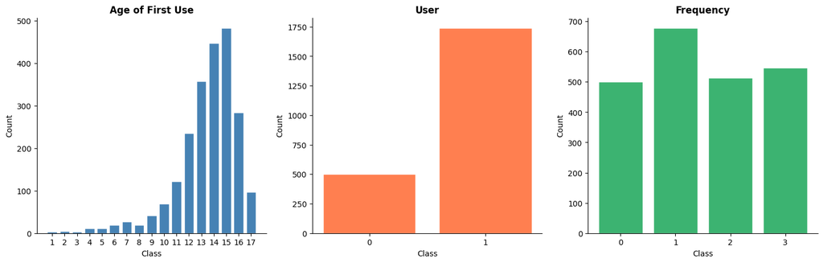

```python
fig = plt.figure(figsize=(18, 5))
target_vars = ['Age of First Use', 'User', 'Frequency']
colors = ['steelblue', 'coral', 'mediumseagreen']

for i, (col, color) in enumerate(zip(target_vars, colors)):
    ax = fig.add_subplot(1, 3, i+1)
    counts = dfdr[col].value_counts().sort_index()
    pcts   = (counts / len(dfdr) * 100).round(1)

    bars = ax.bar(counts.index.astype(str), counts.values,
                  color=color, edgecolor='white')

    ax.set_title(col, fontweight='bold', fontsize=12)
    ax.set_xlabel('Class')
    ax.set_ylabel('Count')
    ax.spines['top'].set_visible(False)
    ax.spines['right'].set_visible(False)
plt.show()
```

## Other variables

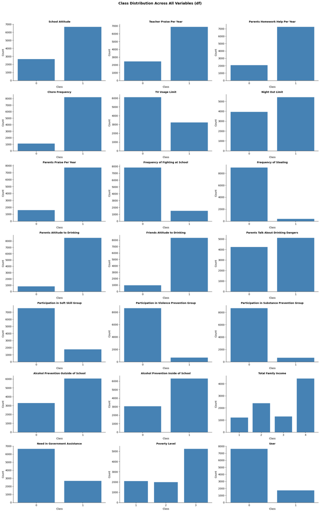

```python
all_cols = [col for col in df.columns if df[col].nunique() <= 10]
n_cols = 3
n_rows = math.ceil(len(all_cols) / n_cols)

fig, axes = plt.subplots(n_rows, n_cols, figsize=(18, n_rows * 4))
axes = axes.flatten()

for i, col in enumerate(all_cols):
    counts = df[col].value_counts().sort_index()

    axes[i].bar(counts.index.astype(str), counts.values,
                color='steelblue', edgecolor='white')
    axes[i].set_title(col, fontsize=10, fontweight='bold')
    axes[i].set_xlabel('Class')
    axes[i].set_ylabel('Count')
    axes[i].spines['top'].set_visible(False)
    axes[i].spines['right'].set_visible(False)

for j in range(i + 1, len(axes)):
    axes[j].set_visible(False)

plt.suptitle('Class Distribution Across All Variables (df)', fontsize=14, fontweight='bold', y=1.02)
plt.tight_layout()
plt.show()
```

# Models

All models are fitted with a base Decision Tree Classifier priort to applying any ensemble methods or parameter tuning.

## Binary Classification

### Binary Decision Tree

```python
b_cols = df.columns.difference(['Days of Use Per Year', 'Age of First Use', 'User'])
X = df[b_cols]
y = df['User']

# Train/test split
X_train, X_test, y_train, y_test = train_test_split(X, y, test_size=0.2, random_state=42, stratify=y)
```

```python
dt_base = DecisionTreeClassifier(random_state=42)
dt_base.fit(X_train, y_train)

y_train_pred_dt = dt_base.predict(X_train)
y_test_pred_dt  = dt_base.predict(X_test)

print(f"Train Accuracy: {accuracy_score(y_train, y_train_pred_dt):.4f}")
print(f"Test Accuracy: {accuracy_score(y_test, y_test_pred_dt):.4f}")
print(f"Difference: {accuracy_score(y_train, y_train_pred_dt) - accuracy_score(y_test, y_test_pred_dt):.4f}")
print(classification_report(y_test, y_test_pred_dt))
```

```
Train Accuracy: 0.9484
Test Accuracy: 0.7319
Difference: 0.2165
              precision    recall  f1-score   support

           0       0.84      0.84      0.84      1528
           1       0.28      0.28      0.28       348

    accuracy                           0.73      1876
   macro avg       0.56      0.56      0.56      1876
weighted avg       0.73      0.73      0.73      1876
```

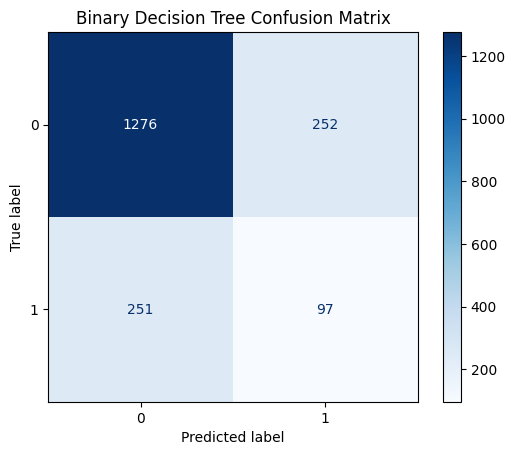

```python
ConfusionMatrixDisplay(confusion_matrix(y_test, y_test_pred_dt)).plot(cmap='Blues')
plt.title('Binary Decision Tree Confusion Matrix')
plt.show()
```

### Tuned Binary Decision Tree

- Train/test difference is now 2.31%, overfitting resolved
- Alcohol user recall improvement, model now catches 2 in 3 users
- Overall accuracy reduced to 64.29%. This is the expected trade-off when forcing attention to minority class
- High false positive rate remains, caused by class imbalance.

```python
# Gridsearch to finetune decision tree parameters
param_grid_dt = {
    'max_depth': [3, 5, 7, 10, 15, None],
    'min_samples_split':[2, 5, 10, 20],
    'min_samples_leaf': [1, 3, 5, 10],
    'criterion':['gini', 'entropy'],
    'class_weight':['balanced', None]}

grid_dt = GridSearchCV(
    estimator=DecisionTreeClassifier(random_state=42),
    param_grid=param_grid_dt,
    cv=5,
    scoring='f1_macro',
    n_jobs=-1,
    verbose=1)
grid_dt.fit(X_train, y_train)

print(f"\nBest Parameters: {grid_dt.best_params_}")
print(f"Best CV Macro F1: {grid_dt.best_score_:.4f}")
```

```
Fitting 5 folds for each of 384 candidates, totalling 1920 fits

Best Parameters: {'class_weight': 'balanced', 'criterion': 'gini', 'max_depth': 7, 'min_samples_leaf': 1, 'min_samples_split': 20}
Best CV Macro F1: 0.5625
```

```python
# Run the model with best parameters!
dt_tuned = grid_dt.best_estimator_
y_train_pred_dt_tuned = dt_tuned.predict(X_train)
y_test_pred_dt_tuned  = dt_tuned.predict(X_test)
```

```python
print(f"Train Accuracy: {accuracy_score(y_train, y_train_pred_dt_tuned):.4f}")
print(f"Test Accuracy: {accuracy_score(y_test,  y_test_pred_dt_tuned):.4f}")
print(f"Difference: {accuracy_score(y_train, y_train_pred_dt_tuned) - accuracy_score(y_test, y_test_pred_dt_tuned):.4f}")
print(classification_report(y_test, y_test_pred_dt_tuned, target_names=['No Use', 'Use']))
```

```
Train Accuracy: 0.6660
Test Accuracy: 0.6429
Difference: 0.0231
              precision    recall  f1-score   support

      No Use       0.89      0.64      0.74      1528
         Use       0.29      0.66      0.41       348

    accuracy                           0.64      1876
   macro avg       0.59      0.65      0.58      1876
weighted avg       0.78      0.64      0.68      1876
```

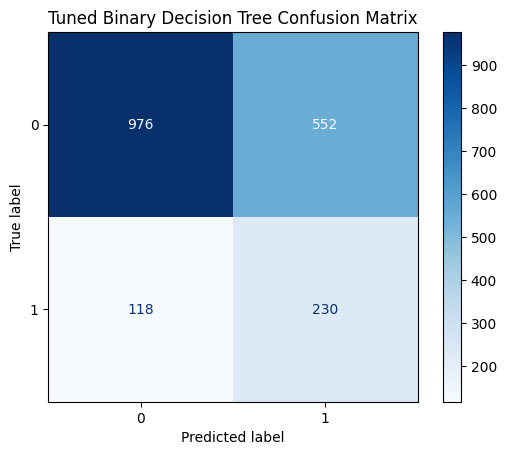

```python
ConfusionMatrixDisplay(confusion_matrix(y_test, y_test_pred_dt_tuned)).plot(cmap='Blues')
plt.title('Tuned Binary Decision Tree Confusion Matrix')
plt.show()
```

[figure not shown]

```python
# Visualize tuned tree
plt.figure(figsize=(24, 8))
plot_tree(dt_tuned, max_depth=3,
          feature_names=list(feature_cols),
          class_names=['No Use', 'Use'],
          filled=True, rounded=True, fontsize=8)
plt.title('Tuned Decision Tree (Depth 3)')
plt.tight_layout()
plt.show()
```

```python
tree_text = export_text(dt_tuned, feature_names=list(b_cols))
print(tree_text)
```

```
|--- TV Usage Limit <= 0.50
|   |--- Frequency of Stealing <= 0.50
|   |   |--- Friends Attitude to Drinking <= 0.50
|   |   |   |--- Total Family Income <= 2.50
|   |   |   |   |--- Parents Attitude to Drinking <= 0.50
|   |   |   |   |   |--- Alcohol Prevention Inside of School <= 0.50
|   |   |   |   |   |   |--- Days of Missed School <= 4.50
|   |   |   |   |   |   |   |--- class: 1
|   |   |   |   |   |   |--- Days of Missed School >  4.50
|   |   |   |   |   |   |   |--- class: 0
|   |   |   |   |   |--- Alcohol Prevention Inside of School >  0.50
|   |   |   |   |   |   |--- Parents Homework Help Per Year <= 0.50
|   |   |   |   |   |   |   |--- class: 1
|   |   |   |   |   |   |--- Parents Homework Help Per Year >  0.50
|   |   |   |   |   |   |   |--- class: 1
|   |   |   |   |--- Parents Attitude to Drinking >  0.50
|   |   |   |   |   |--- Participation in Substance Prevention Group <= 0.50
|   |   |   |   |   |   |--- Days of Missed School <= 6.50
|   |   |   |   |   |   |   |--- class: 1
|   |   |   |   |   |   |--- Days of Missed School >  6.50
|   |   |   |   |   |   |   |--- class: 1
|   |   |   |   |   |--- Participation in Substance Prevention Group >  0.50
|   |   |   |   |   |   |--- class: 0
|   |   |   |--- Total Family Income >  2.50
|   |   |   |   |--- Participation in Violence Prevention Group <= 0.50
|   |   |   |   |   |--- Parents Talk About Drinking Dangers <= 0.50
|   |   |   |   |   |   |--- School Attitude <= 0.50
|   |   |   |   |   |   |   |--- class: 1
|   |   |   |   |   |   |--- School Attitude >  0.50
|   |   |   |   |   |   |   |--- class: 1
|   |   |   |   |   |--- Parents Talk About Drinking Dangers >  0.50
|   |   |   |   |   |   |--- Parents Attitude to Drinking <= 0.50
|   |   |   |   |   |   |   |--- class: 1
|   |   |   |   |   |   |--- Parents Attitude to Drinking >  0.50
|   |   |   |   |   |   |   |--- class: 1
|   |   |   |   |--- Participation in Violence Prevention Group >  0.50
|   |   |   |   |   |--- class: 0
|   |   |--- Friends Attitude to Drinking >  0.50
|   |   |   |--- Poverty Level <= 2.50
|   |   |   |   |--- Parents Praise Per Year <= 0.50
```

[output cut: 150 more lines]

```
|   |   |   |   |--- class: 1
|   |   |--- School Attitude >  0.50
|   |   |   |--- Night Out Limit <= 0.50
|   |   |   |   |--- class: 0
|   |   |   |--- Night Out Limit >  0.50
|   |   |   |   |--- Poverty Level <= 1.50
|   |   |   |   |   |--- class: 1
|   |   |   |   |--- Poverty Level >  1.50
|   |   |   |   |   |--- Total Family Income <= 2.50
|   |   |   |   |   |   |--- class: 0
|   |   |   |   |   |--- Total Family Income >  2.50
|   |   |   |   |   |   |--- Alcohol Prevention Inside of School <= 0.50
|   |   |   |   |   |   |   |--- class: 1
|   |   |   |   |   |   |--- Alcohol Prevention Inside of School >  0.50
|   |   |   |   |   |   |   |--- class: 1
```

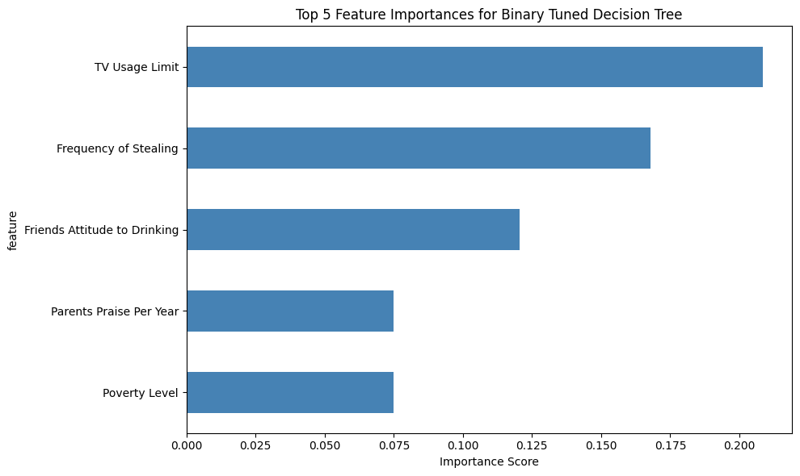

```python
# Feature importance
feat_imp = pd.DataFrame({
    'feature': X_train.columns,
    'importance': dt_tuned.feature_importances_}).sort_values('importance', ascending=False).head(5)

feat_imp.plot(x='feature', kind='barh', legend=False,
              figsize=(10, 6), color='steelblue')
plt.xlabel('Importance Score')
plt.title('Top 5 Feature Importances for Binary Tuned Decision Tree')
plt.gca().invert_yaxis()
plt.tight_layout()
plt.show()
```

### Tuned Binary Random Forest

- Two-pronged imbalance approach: downsampling (3:1 majority to minority ratio) + class_weight='balanced' upweighting
- Train/test difference: 8.80%, which is moderate overfitting, higher than tuned decision tree, reflects ensemble complexity
- False positives remain high, consistent across all models
- Best CV Macro F1: 0.6312, strongest cross-validated performance of all three binary models
- Lower overall accuracy reflects genuine class imbalance difficulty, not model failure

```python
X = df[b_cols]
y = df['User']

X_train, X_test, y_train, y_test = train_test_split(X, y, test_size=0.2, random_state=42, stratify=y)

print("Before downsampling:")
print(y_train.value_counts())
```

```
Before downsampling:
User
0    6112
1    1391
Name: count, dtype: int64
```

**Downsampling**

```python
X_train_full = X_train.copy()
X_train_full['User'] = y_train.values

majority   = X_train_full[X_train_full['User'] == 0]
minority   = X_train_full[X_train_full['User'] == 1]

# Downsample majority to 3x minority
majority_downsampled = resample(
    majority,
    replace=False,
    n_samples=len(minority) * 3,
    random_state=42)

train_balanced = pd.concat([majority_downsampled, minority])
X_train_bal = train_balanced.drop('User', axis=1)
y_train_bal = train_balanced['User']

print(f"\nAfter downsampling:")
print(y_train_bal.value_counts())
```

```
After downsampling:
User
0    4173
1    1391
Name: count, dtype: int64
```

```python
# finding best aprameters
param_grid_rf = {
    'n_estimators': [100, 200, 300],
    'max_depth': [5, 7, 10, None],
    'min_samples_split': [2, 5, 10],
    'min_samples_leaf': [1, 3, 5],
    'criterion': ['gini', 'entropy']}

grid_rf = GridSearchCV(estimator=RandomForestClassifier(class_weight='balanced', random_state=42),
    param_grid=param_grid_rf,
    cv=5,
    scoring='f1_macro',
    n_jobs=-1,
    verbose=1)

# Fit on training data only
grid_rf.fit(X_train_bal, y_train_bal)

print(f"\nBest Parameters: {grid_rf.best_params_}")
print(f"Best CV Macro F1: {grid_rf.best_score_:.4f}")
```

```
Fitting 5 folds for each of 216 candidates, totalling 1080 fits

Best Parameters: {'criterion': 'gini', 'max_depth': None, 'min_samples_leaf': 5, 'min_samples_split': 2, 'n_estimators': 100}
Best CV Macro F1: 0.6312
```

```python
# Fit with the best parameters
rf_best = grid_rf.best_estimator_

y_train_pred_rf = rf_best.predict(X_train_bal)
y_test_pred_rf = rf_best.predict(X_test)
```

```python
print(f"Train Accuracy: {accuracy_score(y_train_bal, y_train_pred_rf):.4f}")
print(f"Test Accuracy: {accuracy_score(y_test, y_test_pred_rf):.4f}")
print(f"Difference:{accuracy_score(y_train_bal, y_train_pred_rf) - accuracy_score(y_test, y_test_pred_rf):.4f}")

print(classification_report(y_test, y_test_pred_rf, target_names=['No Use', 'Use']))
```

```
Train Accuracy: 0.7703
Test Accuracy: 0.6823
Difference:0.0880
              precision    recall  f1-score   support

      No Use       0.88      0.71      0.78      1528
         Use       0.31      0.57      0.40       348

    accuracy                           0.68      1876
   macro avg       0.59      0.64      0.59      1876
weighted avg       0.77      0.68      0.71      1876
```

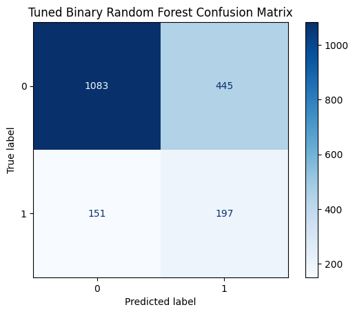

```python
ConfusionMatrixDisplay(confusion_matrix(y_test, y_test_pred_rf)).plot(cmap='Blues')
plt.title('Tuned Binary Random Forest Confusion Matrix')
plt.show()
```

## Multiclass Classification

- GridSearch base DT: max_depth=10, criterion='gini', min_samples_leaf=5, min_samples_split=2
- Base learner already struggling before bagging applied
- Bagging parameters: n_estimators=15, max_samples=1.0, bootstrap=True
- Train 61.53% vs Test 32.14%, which is a 29.39% gap, significant overfitting despite tuning
- Moderate user F1 is 0.15, this is the worst performing class, model essentially unable to identify moderate users
- Elbow plot produced no elbow; no stable optimal point found, diagnostic of weak signal
- Scope restricted to drinkers only following Dr M's feedback discouraging IterativeImputer

```python
# Train Test Split
feature_cols_multi = dfdr.columns.difference(['Frequency', 'User', 'Age of First Use', 'Days of Use Per Year'])

X_multi = dfdr[feature_cols_multi]
y_multi = dfdr['Frequency']

X_train_m, X_test_m, y_train_m, y_test_m = train_test_split(X_multi, y_multi,test_size=0.2,random_state=42,stratify=y_multi)
```

### Multiclass Base Decision Tree

```python
# Best parameters for base decision tree classifier
param_grid_dt = {
    'max_depth': [3, 5, 7, 10],
    'min_samples_split': [2, 5, 10],
    'min_samples_leaf':  [1, 3, 5],
    'criterion': ['gini', 'entropy'],
    'class_weight':['balanced', None]}

grid_dt = GridSearchCV(
    estimator=DecisionTreeClassifier(random_state=42),
    param_grid=param_grid_dt,
    cv=5,
    scoring='f1_macro',
    n_jobs=-1,
    verbose=1)
grid_dt.fit(X_train_m, y_train_m)

print(f"Best DT Parameters: {grid_dt.best_params_}")
print(f"Best CV Macro F1: {grid_dt.best_score_:.4f}")

# Lock in best base estimator
best_dt = grid_dt.best_estimator_
```

```
Fitting 5 folds for each of 144 candidates, totalling 720 fits
Best DT Parameters: {'class_weight': None, 'criterion': 'gini', 'max_depth': 10, 'min_samples_leaf': 5, 'min_samples_split': 2}
Best CV Macro F1: 0.3100
```

```python
y_train_pred_dt = best_dt.predict(X_train_m)
y_test_pred_dt  = best_dt.predict(X_test_m)

print(f"Train Accuracy: {accuracy_score(y_train_m, y_train_pred_dt):.4f}")
print(f"Test Accuracy:  {accuracy_score(y_test_m,  y_test_pred_dt):.4f}")
print(f"Difference: {accuracy_score(y_train_m, y_train_pred_dt) - accuracy_score(y_test_m, y_test_pred_dt):.4f}")
print(classification_report(y_test_m, y_test_pred_dt))
```

```
Train Accuracy: 0.5293
Test Accuracy:  0.3036
Difference: 0.2257
              precision    recall  f1-score   support

           0       0.33      0.32      0.33       100
           1       0.35      0.51      0.41       136
           2       0.17      0.13      0.15       103
           3       0.28      0.20      0.23       109

    accuracy                           0.30       448
   macro avg       0.28      0.29      0.28       448
weighted avg       0.29      0.30      0.29       448
```

### Multiclass Bagging Classifier

```python
# Best parameters for bagging classifier
param_grid_bag = {
    'n_estimators': [5, 10, 15],
    'max_samples':  [0.6, 0.8, 1.0],
    'bootstrap':    [True, False]}

grid_bag = GridSearchCV(
    estimator=BaggingClassifier(
        estimator=best_dt,
        random_state=42),
    param_grid=param_grid_bag,
    cv=5,
    scoring='f1_macro',
    n_jobs=-1,
    verbose=1)
grid_bag.fit(X_train_m, y_train_m)

print(f"\nBest Bagging Parameters: {grid_bag.best_params_}")
print(f"Best CV Macro F1:        {grid_bag.best_score_:.4f}")
```

```
Fitting 5 folds for each of 18 candidates, totalling 90 fits

Best Bagging Parameters: {'bootstrap': True, 'max_samples': 1.0, 'n_estimators': 15}
Best CV Macro F1:        0.3345
```

```python
bag_final = grid_bag.best_estimator_

y_train_pred_final = bag_final.predict(X_train_m)
y_test_pred_final  = bag_final.predict(X_test_m)

print(f"Train Accuracy: {accuracy_score(y_train_m, y_train_pred_final):.4f}")
print(f"Test Accuracy: {accuracy_score(y_test_m,  y_test_pred_final):.4f}")
print(f"Difference: {accuracy_score(y_train_m, y_train_pred_final) - accuracy_score(y_test_m, y_test_pred_final):.4f}")
print(classification_report(y_test_m, y_test_pred_final))
```

```
Train Accuracy: 0.6153
Test Accuracy: 0.3214
Difference: 0.2939
              precision    recall  f1-score   support

           0       0.27      0.25      0.26       100
           1       0.38      0.54      0.44       136
           2       0.19      0.13      0.15       103
           3       0.36      0.30      0.33       109

    accuracy                           0.32       448
   macro avg       0.30      0.30      0.30       448
weighted avg       0.30      0.32      0.31       448
```

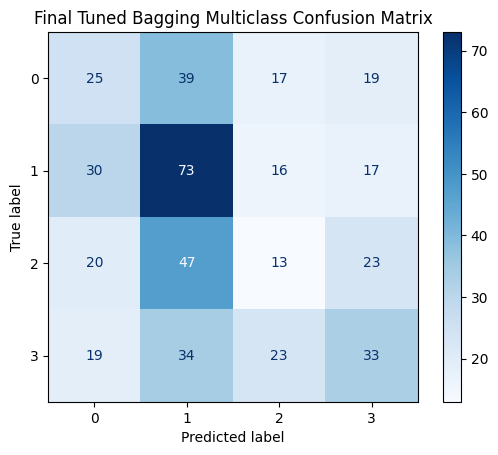

```python
ConfusionMatrixDisplay(confusion_matrix(y_test_m, y_test_pred_final)).plot(cmap='Blues')
plt.title('Final Tuned Bagging Multiclass Confusion Matrix')
plt.show()
```

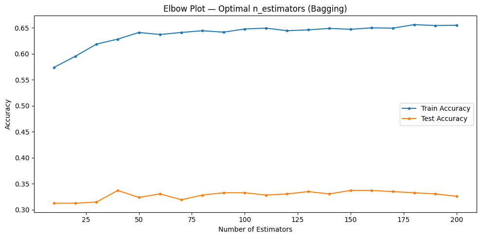

```
Optimal n_estimators: 40
```

```python
train_accs, test_accs = [], []
n_range = range(10, 210, 10)

for n in n_range:
    bag_temp = BaggingClassifier(
        estimator=best_dt,
        n_estimators=n,
        max_samples=0.8,
        bootstrap=True,
        random_state=42)
    bag_temp.fit(X_train_m, y_train_m)
    train_accs.append(accuracy_score(y_train_m, bag_temp.predict(X_train_m)))
    test_accs.append(accuracy_score(y_test_m,   bag_temp.predict(X_test_m)))

plt.figure(figsize=(10, 5))
plt.plot(n_range, train_accs, label='Train Accuracy', marker='o', markersize=3)
plt.plot(n_range, test_accs,  label='Test Accuracy',  marker='o', markersize=3)
plt.xlabel('Number of Estimators')
plt.ylabel('Accuracy')
plt.title('Elbow Plot — Optimal n_estimators (Bagging)')
plt.legend()
plt.tight_layout()
plt.show()

optimal_n = list(n_range)[np.argmax(test_accs)]
print(f"Optimal n_estimators: {optimal_n}")
```

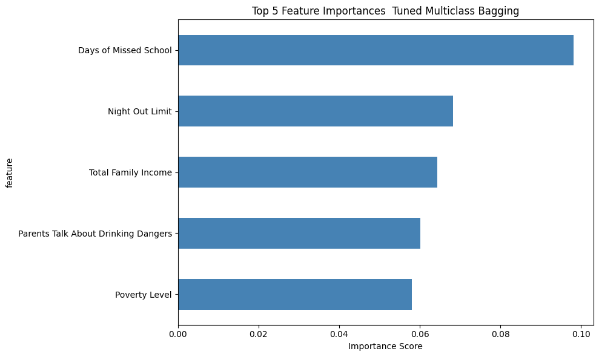

```python
# Average importances across all bagged estimators
importances_multi = np.mean([
    est.feature_importances_
    for est in bag_final.estimators_], axis=0)

feat_imp_multi = pd.DataFrame({
    'feature':    X_train_m.columns,
    'importance': importances_multi}).sort_values('importance', ascending=False)

feat_imp_multi.head(5).plot(
    x='feature', kind='barh',
    legend=False, figsize=(10, 6),
    color='steelblue')
plt.xlabel('Importance Score')
plt.title('Top 5 Feature Importances  Tuned Multiclass Bagging')
plt.gca().invert_yaxis()
plt.tight_layout()
plt.show()
```

### Base Multiclass Boosting

Even tried boosting, still terrible results.

```python
# Baseline boosting classifier
gb_base = GradientBoostingClassifier(random_state=42)
gb_base.fit(X_train_m, y_train_m)

print(f"Train Accuracy: {accuracy_score(y_train_m, gb_base.predict(X_train_m)):.4f}")
print(f"Test Accuracy:  {accuracy_score(y_test_m,  gb_base.predict(X_test_m)):.4f}")
print(classification_report(y_test_m, gb_base.predict(X_test_m)))
```

```
Train Accuracy: 0.5221
Test Accuracy:  0.3326
              precision    recall  f1-score   support

           0       0.28      0.29      0.29       100
           1       0.39      0.53      0.45       136
           2       0.20      0.15      0.17       103
           3       0.40      0.30      0.34       109

    accuracy                           0.33       448
   macro avg       0.32      0.32      0.31       448
weighted avg       0.32      0.33      0.32       448
```

## Regression

### Base Decision Tree Regressor

- fitted with no constraints
- training RMSE of 0.67 and test RMSE of 3.49
- severe overfitting case; unconstrained tree memorized training data so precisely that it essentially predicted near-perfect values for training samples but completely failed to generalize.
- near-zero training MSE of 0.45 on a regression target like age of first use is a red flag. the tree grew deep enough to essentially store individual data points rather than learn patterns.

```python
feature_cols_reg = dfdr.columns.difference(['Age of First Use', 'Frequency', 'User', 'Days of Use Per Year'])
X_reg = dfdr[feature_cols_reg]
y_reg = dfdr['Age of First Use']


X_train_r, X_test_r, y_train_r, y_test_r = train_test_split(X_reg, y_reg, test_size=0.2, random_state=42)
```

```python
# Fit the model
dt_reg_base = DecisionTreeRegressor(random_state=42)
dt_reg_base.fit(X_train_r, y_train_r)

y_train_pred_dt = dt_reg_base.predict(X_train_r)
y_test_pred_dt  = dt_reg_base.predict(X_test_r)
```

```python
train_mse_dt  = mean_squared_error(y_train_r, y_train_pred_dt)
test_mse_dt   = mean_squared_error(y_test_r,  y_test_pred_dt)
train_rmse_dt = np.sqrt(train_mse_dt)
test_rmse_dt  = np.sqrt(test_mse_dt)

print(f"Train MSE: {train_mse_dt:.4f} | Train RMSE: {train_rmse_dt:.4f} ")
print(f"Test MSE: {test_mse_dt:.4f} | Test RMSE:  {test_rmse_dt:.4f} ")
print(f"Difference: {train_mse_dt - test_mse_dt:.4f}")
```

```
Train MSE: 0.4482  | Train RMSE: 0.6695
Test MSE: 12.2147   | Test RMSE:  3.4949
Difference: -11.7665
```

### Tuned Decision Tree Regressor

- gridSearch across parameter combinations identified optimal settings of max depth 3, squared error criterion, min samples leaf of 10, and min samples split of 2, producing a best cross-validated RMSE of 2.47.
- the squared error criterion minimizes the mean squared error at each split
- tuning resolved the overfitting dramatically. the train-test difference collapsed from -11.77 to just 0.35, with train RMSE of 2.41 and test RMSE of 2.33.
- shallow max depth of 3 prevented the tree from growing complex enough to memorize training data.
- the cross-validated RMSE of 2.47 is consistent with the test RMSE of 2.33, confirming the model generalizes reliably

```python
param_grid_dt_reg = {
    'max_depth': [3, 5, 7, 10, None],
    'min_samples_split': [2, 5, 10, 20],
    'min_samples_leaf': [1, 3, 5, 10],
    'criterion': ['squared_error']}

grid_dt_reg = GridSearchCV(
    estimator=DecisionTreeRegressor(random_state=42),
    param_grid=param_grid_dt_reg,
    cv=5,
    scoring='neg_mean_squared_error',
    n_jobs=-1,
    verbose=1)
grid_dt_reg.fit(X_train_r, y_train_r)

print(f"\nBest DT Parameters: {grid_dt_reg.best_params_}")
print(f"Best CV MSE: {-grid_dt_reg.best_score_:.4f}")
print(f"Best CV RMSE: {np.sqrt(-grid_dt_reg.best_score_):.4f}")

best_dt_reg = grid_dt_reg.best_estimator_
```

```
Fitting 5 folds for each of 80 candidates, totalling 400 fits

Best DT Parameters: {'criterion': 'squared_error', 'max_depth': 3, 'min_samples_leaf': 10, 'min_samples_split': 2}
Best CV MSE: 6.0771
Best CV RMSE: 2.4652
```

```python
y_train_pred_dt_tuned = best_dt_reg.predict(X_train_r)
y_test_pred_dt_tuned  = best_dt_reg.predict(X_test_r)

train_mse_dt_t = mean_squared_error(y_train_r, y_train_pred_dt_tuned)
test_mse_dt_t = mean_squared_error(y_test_r,  y_test_pred_dt_tuned)

print(f"Train MSE: {train_mse_dt_t:.4f} | Train RMSE: {np.sqrt(train_mse_dt_t):.4f}")
print(f"Test MSE: {test_mse_dt_t:.4f} | Test RMSE:  {np.sqrt(test_mse_dt_t):.4f}")
print(f"Difference: {train_mse_dt_t - test_mse_dt_t:.4f}")
```

```
Train MSE:  5.7876  | Train RMSE: 2.4057
Test MSE:   5.4330   | Test RMSE:  2.3309
Difference: 0.3546
```

### Base Gradient Boosting Regressor

- no tuning applied
- train RMSE of 2.22 and test RMSE of 2.34, with a small negative difference of -0.55
- base boosting model already outperforms the base decision tree substantially without any tuning, demonstrating the inherent strength of sequential ensemble learning even in its default configuration.

```python
gb_base = GradientBoostingRegressor(random_state=42)
gb_base.fit(X_train_r, y_train_r)

y_train_pred_gb = gb_base.predict(X_train_r)
y_test_pred_gb  = gb_base.predict(X_test_r)

train_mse_gb  = mean_squared_error(y_train_r, y_train_pred_gb)
test_mse_gb   = mean_squared_error(y_test_r,  y_test_pred_gb)

print(f"Train MSE: {train_mse_gb:.4f}  | Train RMSE: {np.sqrt(train_mse_gb):.4f}")
print(f"Test MSE: {test_mse_gb:.4f}   | Test RMSE:  {np.sqrt(test_mse_gb):.4f}")
print(f"Difference: {train_mse_gb - test_mse_gb:.4f}")
```

```
Train MSE: 4.9494  | Train RMSE: 2.2247
Test MSE: 5.4987   | Test RMSE:  2.3449
Difference: -0.5494
```

### Tuned Gradient Boosting Regressor

- identified optimal tree parameters of max depth 3, min samples split of 5, and min samples leaf of 1
- followed by a full GridSearch locking in a learning rate of 0.1 and 30 estimators.
- train RMSE of 2.32 and test RMSE of 2.33, with an almost negligible difference of -0.02 (the closest train-test alignment of all four models)
- cross-validation across 5 folds produced a mean RMSE of 2.41 with a standard deviation of just 0.06
- cv confirms consistency and stability across different data subsets
- the model's predictions deviate from the true age of first use by approximately 2.33 years on average

```python
# Finding optimal depth, split and leaf
# Gridsearch is split up to reduce run time
param_grid_gb = {
    'max_depth': [3, 5, 7],
    'min_samples_split': [2, 5, 10],
    'min_samples_leaf':  [1, 3, 5],}

grid_gb_dt = GridSearchCV(
    estimator=GradientBoostingRegressor(
        n_estimators=100,
        learning_rate=0.1,
        random_state=42),
    param_grid=param_grid_gb,
    cv=5,
    scoring='neg_mean_squared_error',
    n_jobs=-1,
    verbose=1)
grid_gb_dt.fit(X_train_r, y_train_r)

print(f"\nBest Tree Parameters: {grid_gb_dt.best_params_}")
print(f"Best CV RMSE: {np.sqrt(-grid_gb_dt.best_score_):.4f}")

best_tree_params = grid_gb_dt.best_params_
```

```
Fitting 5 folds for each of 27 candidates, totalling 135 fits

Best Tree Parameters: {'max_depth': 3, 'min_samples_leaf': 1, 'min_samples_split': 5}
Best CV RMSE: 2.4574
```

```python
# Finding optimal number of estimators and learning rate
param_grid_gb_lr = {
    'n_estimators':  [10, 20, 30],
    'learning_rate': [0.001, 0.01, 0.05, 0.1]}

grid_gb_final = GridSearchCV(
    estimator=GradientBoostingRegressor(
        max_depth=best_tree_params['max_depth'],
        min_samples_split=best_tree_params['min_samples_split'],
        min_samples_leaf=best_tree_params['min_samples_leaf'],
        random_state=42),
    param_grid=param_grid_gb_lr,
    cv=5,
    scoring='neg_mean_squared_error',
    n_jobs=-1,
    verbose=1)
grid_gb_final.fit(X_train_r, y_train_r)

print(f"\nBest Final Parameters: {grid_gb_final.best_params_}")
print(f"Best CV RMSE: {np.sqrt(-grid_gb_final.best_score_):.4f}")
```

```
Fitting 5 folds for each of 12 candidates, totalling 60 fits

Best Final Parameters: {'learning_rate': 0.1, 'n_estimators': 30}
Best CV RMSE: 2.4265
```

```python
# Fit the model
gb_final = grid_gb_final.best_estimator_

y_train_pred_final = gb_final.predict(X_train_r)
y_test_pred_final  = gb_final.predict(X_test_r)

train_mse_f  = mean_squared_error(y_train_r, y_train_pred_final)
test_mse_f   = mean_squared_error(y_test_r,  y_test_pred_final)
train_rmse_f = np.sqrt(train_mse_f)
test_rmse_f  = np.sqrt(test_mse_f)

print(f"Train MSE:{train_mse_f:.4f}  | Train RMSE: {train_rmse_f:.4f}")
print(f"Test MSE:{test_mse_f:.4f}   | Test RMSE:  {test_rmse_f:.4f}")
print(f"Difference:{train_mse_f - test_mse_f:.4f}")
```

```
Train MSE:5.3924  | Train RMSE: 2.3221
Test MSE:5.4172   | Test RMSE:  2.3275
Difference:-0.0248
```

```python
# Cross validation
cv_scores = cross_val_score(
    gb_final, X_reg, y_reg,
    cv=5,
    scoring='neg_mean_squared_error')
cv_rmse = np.sqrt(-cv_scores)
print(f"\nCV RMSE per fold: {cv_rmse.round(4)}")
print(f"Mean CV RMSE: {cv_rmse.mean():.4f}")
print(f"Std CV RMSE: {cv_rmse.std():.4f}")
```

```
CV RMSE per fold: [2.4486 2.3683 2.486  2.4344 2.3128]
Mean CV RMSE: 2.4100
Std CV RMSE: 0.0617
```

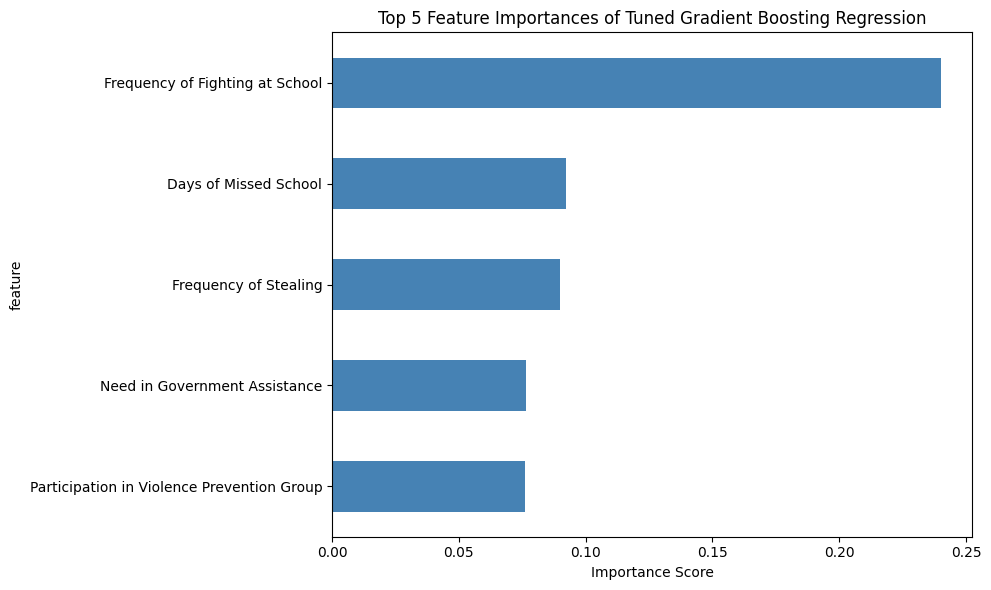

```python
# Feature importance
feat_imp_gb = pd.DataFrame({
    'feature': X_train_r.columns,
    'importance': gb_final.feature_importances_}).sort_values('importance', ascending=False)

feat_imp_gb.head(5).plot(
    x='feature', kind='barh',
    legend=False, figsize=(10, 6),
    color='steelblue')
plt.xlabel('Importance Score')
plt.title('Top 5 Feature Importances of Tuned Gradient Boosting Regression')
plt.gca().invert_yaxis()
plt.tight_layout()
plt.show()
```

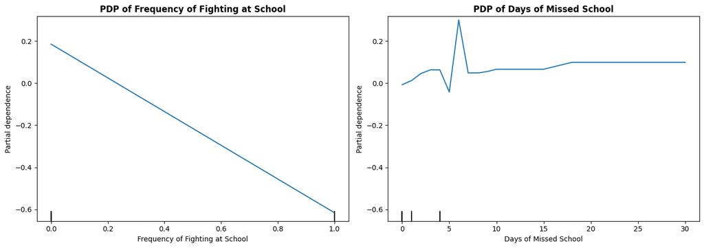

```python
# Partial dependency plots
fig, axes = plt.subplots(1, 2, figsize=(14, 5))

PartialDependenceDisplay.from_estimator(
    gb_final,
    X_train_r,
    features=top_2_reg,
    ax=axes,
    grid_resolution=50)

axes[0].set_title(f'PDP of {top_2_reg[0]}', fontweight='bold')
axes[1].set_title(f'PDP of {top_2_reg[1]}', fontweight='bold')
plt.tight_layout()
plt.show()
```

## Comparison between models

[output not shown]

# Limitations

# Conclusion

- Models applied:
  - Binary decision tree: meaningful generalization despite severe class imbalance
  - Multiclass bagging: weakest performer, limited by dataset and class definition constraints.
  - Regression gradient boosting: strongest performer
- Consistent predictors across all models:
  - Parental involvement
  - School engagement
  - Delinquent behavior
  - Socioeconomic conditions
- Youth alcohol use is as much a social phenomenon as a behavioral one. Prevention requires multi-level, community-wide approaches